# Risk Factor Analysis

## Outcome Variable

**Outcome Variable:** haz

## Predictor Variables

**Intervention Variable:** impfloor

**Adjustment Set:**

- arm
- sex
- W_mage
- meducyrs
- feducyrs
- hhwealth_quart
- hfoodsec
- W_mhtcm
- W_mwtkg
- W_mbmi
- W_nrooms
- W_nchldlt5
- W_parity
- impsan
- safeh20
- delta_W_mage
- delta_meducyrs
- delta_feducyrs
- delta_hhwealth_quart
- delta_hfoodsec
- delta_W_mhtcm
- delta_W_mwtkg
- delta_W_mbmi
- delta_W_nrooms
- delta_W_nchldlt5
- delta_W_parity
- delta_impsan
- delta_safeh20

## Stratifying Variables

The analysis was stratified on these variable(s):

- agecat
- studyid
- country

## Data Summary

| agecat | studyid | country | impfloor | n_cell | n |
| --- | --- | --- | --- | --- | --- |
| Birth | CMC-V-BCS-2002 | INDIA | 1 | 72 | 72 |
| Birth | CMC-V-BCS-2002 | INDIA | 0 | 0 | 72 |
| Birth | CONTENT | PERU | 1 | 2 | 2 |
| Birth | CONTENT | PERU | 0 | 0 | 2 |
| Birth | GMS-Nepal | NEPAL | 1 | 100 | 544 |
| Birth | GMS-Nepal | NEPAL | 0 | 444 | 544 |
| Birth | IRC | INDIA | 1 | 287 | 287 |
| Birth | IRC | INDIA | 0 | 0 | 287 |
| Birth | JiVitA-3 | BANGLADESH | 1 | 1394 | 22399 |
| Birth | JiVitA-3 | BANGLADESH | 0 | 21005 | 22399 |
| Birth | JiVitA-4 | BANGLADESH | 1 | 307 | 2820 |
| Birth | JiVitA-4 | BANGLADESH | 0 | 2513 | 2820 |
| Birth | MAL-ED | BANGLADESH | 1 | 196 | 213 |
| Birth | MAL-ED | BANGLADESH | 0 | 17 | 213 |
| Birth | MAL-ED | BRAZIL | 1 | 58 | 60 |
| Birth | MAL-ED | BRAZIL | 0 | 2 | 60 |
| Birth | MAL-ED | INDIA | 1 | 35 | 41 |
| Birth | MAL-ED | INDIA | 0 | 6 | 41 |
| Birth | MAL-ED | NEPAL | 1 | 9 | 25 |
| Birth | MAL-ED | NEPAL | 0 | 16 | 25 |
| Birth | MAL-ED | PERU | 1 | 39 | 215 |
| Birth | MAL-ED | PERU | 0 | 176 | 215 |
| Birth | MAL-ED | SOUTH AFRICA | 1 | 87 | 96 |
| Birth | MAL-ED | SOUTH AFRICA | 0 | 9 | 96 |
| Birth | MAL-ED | TANZANIA, UNITED REPUBLIC OF | 1 | 7 | 119 |
| Birth | MAL-ED | TANZANIA, UNITED REPUBLIC OF | 0 | 112 | 119 |
| Birth | NIH-Birth | BANGLADESH | 1 | 533 | 605 |
| Birth | NIH-Birth | BANGLADESH | 0 | 72 | 605 |
| Birth | NIH-Crypto | BANGLADESH | 1 | 558 | 732 |
| Birth | NIH-Crypto | BANGLADESH | 0 | 174 | 732 |

[output cut: 66 more lines]

The following strata were considered:

- agecat: 24 months, studyid: CMC-V-BCS-2002, country: INDIA
- agecat: 24 months, studyid: CONTENT, country: PERU
- agecat: 24 months, studyid: GMS-Nepal, country: NEPAL
- agecat: 24 months, studyid: IRC, country: INDIA
- agecat: 24 months, studyid: JiVitA-3, country: BANGLADESH
- agecat: 24 months, studyid: JiVitA-4, country: BANGLADESH
- agecat: 24 months, studyid: MAL-ED, country: BANGLADESH
- agecat: 24 months, studyid: MAL-ED, country: BRAZIL
- agecat: 24 months, studyid: MAL-ED, country: INDIA
- agecat: 24 months, studyid: MAL-ED, country: NEPAL
- agecat: 24 months, studyid: MAL-ED, country: PERU
- agecat: 24 months, studyid: MAL-ED, country: SOUTH AFRICA
- agecat: 24 months, studyid: MAL-ED, country: TANZANIA, UNITED REPUBLIC OF
- agecat: 24 months, studyid: NIH-Birth, country: BANGLADESH
- agecat: 24 months, studyid: NIH-Crypto, country: BANGLADESH
- agecat: 24 months, studyid: PROVIDE, country: BANGLADESH
- agecat: 6 months, studyid: CMC-V-BCS-2002, country: INDIA
- agecat: 6 months, studyid: CONTENT, country: PERU
- agecat: 6 months, studyid: GMS-Nepal, country: NEPAL
- agecat: 6 months, studyid: IRC, country: INDIA
- agecat: 6 months, studyid: JiVitA-3, country: BANGLADESH
- agecat: 6 months, studyid: JiVitA-4, country: BANGLADESH
- agecat: 6 months, studyid: MAL-ED, country: BANGLADESH
- agecat: 6 months, studyid: MAL-ED, country: BRAZIL
- agecat: 6 months, studyid: MAL-ED, country: INDIA
- agecat: 6 months, studyid: MAL-ED, country: NEPAL
- agecat: 6 months, studyid: MAL-ED, country: PERU
- agecat: 6 months, studyid: MAL-ED, country: SOUTH AFRICA
- agecat: 6 months, studyid: MAL-ED, country: TANZANIA, UNITED REPUBLIC OF
- agecat: 6 months, studyid: NIH-Birth, country: BANGLADESH
- agecat: 6 months, studyid: NIH-Crypto, country: BANGLADESH
- agecat: 6 months, studyid: PROVIDE, country: BANGLADESH
- agecat: Birth, studyid: CMC-V-BCS-2002, country: INDIA
- agecat: Birth, studyid: CONTENT, country: PERU
- agecat: Birth, studyid: GMS-Nepal, country: NEPAL
- agecat: Birth, studyid: IRC, country: INDIA
- agecat: Birth, studyid: JiVitA-3, country: BANGLADESH
- agecat: Birth, studyid: JiVitA-4, country: BANGLADESH
- agecat: Birth, studyid: MAL-ED, country: BANGLADESH
- agecat: Birth, studyid: MAL-ED, country: BRAZIL
- agecat: Birth, studyid: MAL-ED, country: INDIA
- agecat: Birth, studyid: MAL-ED, country: NEPAL
- agecat: Birth, studyid: MAL-ED, country: PERU
- agecat: Birth, studyid: MAL-ED, country: SOUTH AFRICA
- agecat: Birth, studyid: MAL-ED, country: TANZANIA, UNITED REPUBLIC OF
- agecat: Birth, studyid: NIH-Birth, country: BANGLADESH
- agecat: Birth, studyid: NIH-Crypto, country: BANGLADESH
- agecat: Birth, studyid: PROVIDE, country: BANGLADESH

### Dropped Strata

- agecat: Birth, studyid: CMC-V-BCS-2002, country: INDIA
- agecat: Birth, studyid: CONTENT, country: PERU
- agecat: Birth, studyid: IRC, country: INDIA
- agecat: Birth, studyid: MAL-ED, country: BRAZIL
- agecat: 6 months, studyid: CMC-V-BCS-2002, country: INDIA
- agecat: 6 months, studyid: IRC, country: INDIA
- agecat: 6 months, studyid: MAL-ED, country: BRAZIL
- agecat: 24 months, studyid: CMC-V-BCS-2002, country: INDIA
- agecat: 24 months, studyid: IRC, country: INDIA
- agecat: 24 months, studyid: MAL-ED, country: BRAZIL

## Methods Detail

We’re interested in the causal parameters $E[Y_a]$ for all values of $a \in \mathcal{A}$. These parameters represent the mean outcome if, possibly contrary to fact, we intervened to set all units to have $A=a$. Under the randomization and positivity assumptions, these are identified by the statistical parameters $\psi_a=E_W[E_{Y|A,W}(Y|A=a,W)]$. In addition, we’re interested in the mean of $Y$, $E[Y]$ under no intervention (the observed mean). We will estimate these parameters by using SuperLearner to fit the relevant likelihood factors – $E_{Y|A,W}(Y|A=a,W)$ and $p(A=a|W)$, and then updating our likelihood fit using a joint TMLE.

For unadjusted analyses ($W=\{\}$), initial likelihoods were estimated using Lrnr_glm to estimate the simple $E(Y|A)$ and Lrnr_mean to estimate $p(A)$. For adjusted analyses, a small library containing Lrnr_glmnet, Lrnr_xgboost, and Lrnr_mean was used.

Having estimated these parameters, we will then use the delta method to estimate relative risks and attributable risks relative to a prespecified baseline level of $A$.

# Results Detail

## Results Plots

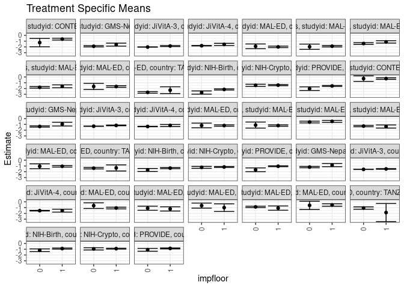

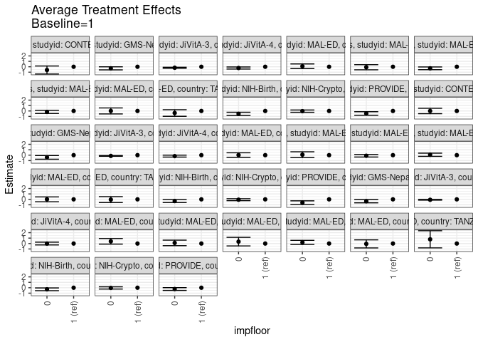

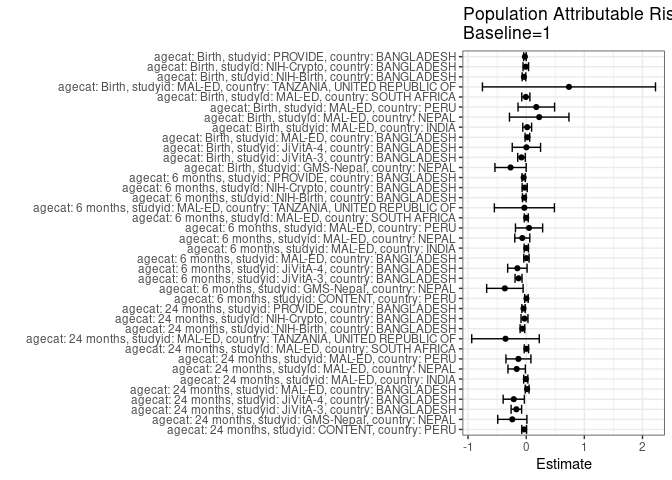

## Results Table

### Parameter: TSM

| agecat | studyid | country | intervention_level | baseline_level | estimate | ci_lower | ci_upper |
| --- | --- | --- | --- | --- | --- | --- | --- |
| Birth | GMS-Nepal | NEPAL | 1 | NA | -0.8490029 | -1.1241189 | -0.5738868 |
| Birth | GMS-Nepal | NEPAL | 0 | NA | -1.1914857 | -1.3040830 | -1.0788885 |
| Birth | JiVitA-3 | BANGLADESH | 1 | NA | -1.5089515 | -1.5750993 | -1.4428037 |
| Birth | JiVitA-3 | BANGLADESH | 0 | NA | -1.5882019 | -1.6080847 | -1.5683191 |
| Birth | JiVitA-4 | BANGLADESH | 1 | NA | -1.5272584 | -1.7806468 | -1.2738700 |
| Birth | JiVitA-4 | BANGLADESH | 0 | NA | -1.5295428 | -1.5840211 | -1.4750644 |
| Birth | MAL-ED | BANGLADESH | 1 | NA | -1.0735309 | -1.2167619 | -0.9302999 |
| Birth | MAL-ED | BANGLADESH | 0 | NA | -0.6635948 | -1.1540193 | -0.1731703 |
| Birth | MAL-ED | INDIA | 1 | NA | -1.2242857 | -1.5919558 | -0.8566156 |
| Birth | MAL-ED | INDIA | 0 | NA | -1.1066667 | -1.4622060 | -0.7511274 |
| Birth | MAL-ED | NEPAL | 1 | NA | -1.0066667 | -1.6704675 | -0.3428658 |
| Birth | MAL-ED | NEPAL | 0 | NA | -0.6568750 | -1.0897018 | -0.2240482 |
| Birth | MAL-ED | PERU | 1 | NA | -1.0881277 | -1.4543891 | -0.7218663 |
| Birth | MAL-ED | PERU | 0 | NA | -0.8772800 | -0.9989236 | -0.7556365 |
| Birth | MAL-ED | SOUTH AFRICA | 1 | NA | -0.5463218 | -0.7573107 | -0.3353330 |
| Birth | MAL-ED | SOUTH AFRICA | 0 | NA | -0.6111111 | -1.3247632 | 0.1025410 |
| Birth | MAL-ED | TANZANIA, UNITED REPUBLIC OF | 1 | NA | -1.8571429 | -3.4252117 | -0.2890740 |
| Birth | MAL-ED | TANZANIA, UNITED REPUBLIC OF | 0 | NA | -1.0753571 | -1.2760805 | -0.8746338 |
| Birth | NIH-Birth | BANGLADESH | 1 | NA | -0.8903475 | -0.9849896 | -0.7957054 |
| Birth | NIH-Birth | BANGLADESH | 0 | NA | -1.1818875 | -1.4176618 | -0.9461131 |
| Birth | NIH-Crypto | BANGLADESH | 1 | NA | -0.9027855 | -0.9817699 | -0.8238012 |
| Birth | NIH-Crypto | BANGLADESH | 0 | NA | -0.9385038 | -1.1307801 | -0.7462275 |
| Birth | PROVIDE | BANGLADESH | 1 | NA | -0.8633146 | -0.9422996 | -0.7843295 |
| Birth | PROVIDE | BANGLADESH | 0 | NA | -1.1027355 | -1.3446700 | -0.8608011 |
| 6 months | CONTENT | PERU | 1 | NA | -0.2824949 | -0.4199450 | -0.1450448 |
| 6 months | CONTENT | PERU | 0 | NA | -0.2840586 | -0.7627258 | 0.1946085 |
| 6 months | GMS-Nepal | NEPAL | 1 | NA | -0.9558667 | -1.2781507 | -0.6335827 |
| 6 months | GMS-Nepal | NEPAL | 0 | NA | -1.3641230 | -1.4724585 | -1.2557874 |
| 6 months | JiVitA-3 | BANGLADESH | 1 | NA | -1.1819440 | -1.2416053 | -1.1222828 |
| 6 months | JiVitA-3 | BANGLADESH | 0 | NA | -1.3217976 | -1.3471088 | -1.2964864 |
| 6 months | JiVitA-4 | BANGLADESH | 1 | NA | -1.1923464 | -1.3647342 | -1.0199585 |
| 6 months | JiVitA-4 | BANGLADESH | 0 | NA | -1.3696944 | -1.4112328 | -1.3281561 |
| 6 months | MAL-ED | BANGLADESH | 1 | NA | -1.2068401 | -1.3259238 | -1.0877565 |
| 6 months | MAL-ED | BANGLADESH | 0 | NA | -1.1870045 | -1.5907442 | -0.7832648 |
| 6 months | MAL-ED | INDIA | 1 | NA | -1.2087911 | -1.3304291 | -1.0871530 |
| 6 months | MAL-ED | INDIA | 0 | NA | -1.1243713 | -1.6474081 | -0.6013344 |
| 6 months | MAL-ED | NEPAL | 1 | NA | -0.4865154 | -0.6643314 | -0.3086995 |
| 6 months | MAL-ED | NEPAL | 0 | NA | -0.5976951 | -0.7486114 | -0.4467789 |
| 6 months | MAL-ED | PERU | 1 | NA | -1.3740615 | -1.6437842 | -1.1043388 |
| 6 months | MAL-ED | PERU | 0 | NA | -1.2999509 | -1.4182881 | -1.1816137 |
| 6 months | MAL-ED | SOUTH AFRICA | 1 | NA | -1.0555908 | -1.1927771 | -0.9184045 |
| 6 months | MAL-ED | SOUTH AFRICA | 0 | NA | -1.0531643 | -1.4764910 | -0.6298377 |
| 6 months | MAL-ED | TANZANIA, UNITED REPUBLIC OF | 1 | NA | -1.3390129 | -1.8677459 | -0.8102799 |
| 6 months | MAL-ED | TANZANIA, UNITED REPUBLIC OF | 0 | NA | -1.3823089 | -1.5090948 | -1.2555231 |
| 6 months | NIH-Birth | BANGLADESH | 1 | NA | -1.3731826 | -1.4679369 | -1.2784282 |
| 6 months | NIH-Birth | BANGLADESH | 0 | NA | -1.6862485 | -1.9406542 | -1.4318429 |
| 6 months | NIH-Crypto | BANGLADESH | 1 | NA | -1.1726926 | -1.2529378 | -1.0924474 |
| 6 months | NIH-Crypto | BANGLADESH | 0 | NA | -1.2345026 | -1.3971903 | -1.0718150 |
| 6 months | PROVIDE | BANGLADESH | 1 | NA | -1.0481061 | -1.1230243 | -0.9731878 |
| 6 months | PROVIDE | BANGLADESH | 0 | NA | -1.6609932 | -1.9914963 | -1.3304902 |
| 24 months | CONTENT | PERU | 1 | NA | -0.6522050 | -0.8087071 | -0.4957030 |
| 24 months | CONTENT | PERU | 0 | NA | -1.2519345 | -1.9771308 | -0.5267382 |
| 24 months | GMS-Nepal | NEPAL | 1 | NA | -1.6010006 | -1.8588452 | -1.3431559 |
| 24 months | GMS-Nepal | NEPAL | 0 | NA | -1.8905322 | -2.0058651 | -1.7751992 |
| 24 months | JiVitA-3 | BANGLADESH | 1 | NA | -1.8444641 | -1.9346884 | -1.7542398 |
| 24 months | JiVitA-3 | BANGLADESH | 0 | NA | -2.0238417 | -2.0535374 | -1.9941460 |
| 24 months | JiVitA-4 | BANGLADESH | 1 | NA | -1.5665957 | -1.7553986 | -1.3777929 |
| 24 months | JiVitA-4 | BANGLADESH | 0 | NA | -1.7952428 | -1.8331908 | -1.7572948 |
| 24 months | MAL-ED | BANGLADESH | 1 | NA | -1.9943807 | -2.1275577 | -1.8612036 |
| 24 months | MAL-ED | BANGLADESH | 0 | NA | -1.8967336 | -2.3024965 | -1.4909708 |
| 24 months | MAL-ED | INDIA | 1 | NA | -1.8790486 | -2.0074112 | -1.7506859 |
| 24 months | MAL-ED | INDIA | 0 | NA | -1.9664755 | -2.4214247 | -1.5115264 |
| 24 months | MAL-ED | NEPAL | 1 | NA | -1.1291106 | -1.3309286 | -0.9272927 |
| 24 months | MAL-ED | NEPAL | 0 | NA | -1.4159347 | -1.5656968 | -1.2661726 |
| 24 months | MAL-ED | PERU | 1 | NA | -1.6191268 | -1.8712769 | -1.3669766 |
| 24 months | MAL-ED | PERU | 0 | NA | -1.7939271 | -1.9293058 | -1.6585484 |
| 24 months | MAL-ED | SOUTH AFRICA | 1 | NA | -1.6486776 | -1.7896500 | -1.5077051 |
| 24 months | MAL-ED | SOUTH AFRICA | 0 | NA | -1.6425907 | -2.1750376 | -1.1101437 |
| 24 months | MAL-ED | TANZANIA, UNITED REPUBLIC OF | 1 | NA | -2.2874504 | -2.8778852 | -1.6970157 |
| 24 months | MAL-ED | TANZANIA, UNITED REPUBLIC OF | 0 | NA | -2.6621838 | -2.8033100 | -2.5210576 |
| 24 months | NIH-Birth | BANGLADESH | 1 | NA | -2.1588297 | -2.2668231 | -2.0508364 |
| 24 months | NIH-Birth | BANGLADESH | 0 | NA | -2.6924745 | -2.9717465 | -2.4132025 |
| 24 months | NIH-Crypto | BANGLADESH | 1 | NA | -1.4121201 | -1.5100858 | -1.3141543 |
| 24 months | NIH-Crypto | BANGLADESH | 0 | NA | -1.4462685 | -1.6357985 | -1.2567386 |
| 24 months | PROVIDE | BANGLADESH | 1 | NA | -1.5564716 | -1.6417044 | -1.4712389 |
| 24 months | PROVIDE | BANGLADESH | 0 | NA | -2.0212696 | -2.3319068 | -1.7106324 |

### Parameter: E(Y)

| agecat | studyid | country | intervention_level | baseline_level | estimate | ci_lower | ci_upper |
| --- | --- | --- | --- | --- | --- | --- | --- |
| Birth | GMS-Nepal | NEPAL | NA | NA | -1.1177022 | -1.2075344 | -1.0278700 |
| Birth | JiVitA-3 | BANGLADESH | NA | NA | -1.5895451 | -1.6088186 | -1.5702715 |
| Birth | JiVitA-4 | BANGLADESH | NA | NA | -1.5236135 | -1.5727559 | -1.4744711 |
| Birth | MAL-ED | BANGLADESH | NA | NA | -1.0530516 | -1.1896058 | -0.9164975 |
| Birth | MAL-ED | INDIA | NA | NA | -1.2070732 | -1.5254820 | -0.8886644 |
| Birth | MAL-ED | NEPAL | NA | NA | -0.7828000 | -1.1547571 | -0.4108429 |
| Birth | MAL-ED | PERU | NA | NA | -0.9141395 | -1.0364098 | -0.7918693 |
| Birth | MAL-ED | SOUTH AFRICA | NA | NA | -0.5523958 | -0.7550074 | -0.3497843 |
| Birth | MAL-ED | TANZANIA, UNITED REPUBLIC OF | NA | NA | -1.1213445 | -1.3341800 | -0.9085090 |
| Birth | NIH-Birth | BANGLADESH | NA | NA | -0.9289256 | -1.0178691 | -0.8399821 |
| Birth | NIH-Crypto | BANGLADESH | NA | NA | -0.9094945 | -0.9809370 | -0.8380521 |
| Birth | PROVIDE | BANGLADESH | NA | NA | -0.8851020 | -0.9601332 | -0.8100709 |
| 6 months | CONTENT | PERU | NA | NA | -0.2785256 | -0.4098735 | -0.1471776 |
| 6 months | GMS-Nepal | NEPAL | NA | NA | -1.3225094 | -1.4115793 | -1.2334396 |
| 6 months | JiVitA-3 | BANGLADESH | NA | NA | -1.3134597 | -1.3365976 | -1.2903219 |
| 6 months | JiVitA-4 | BANGLADESH | NA | NA | -1.3440174 | -1.3812821 | -1.3067527 |
| 6 months | MAL-ED | BANGLADESH | NA | NA | -1.2026806 | -1.3203025 | -1.0850586 |
| 6 months | MAL-ED | INDIA | NA | NA | -1.2070638 | -1.3255909 | -1.0885368 |
| 6 months | MAL-ED | NEPAL | NA | NA | -0.5534862 | -0.6681825 | -0.4387899 |
| 6 months | MAL-ED | PERU | NA | NA | -1.3248549 | -1.4336721 | -1.2160378 |
| 6 months | MAL-ED | SOUTH AFRICA | NA | NA | -1.0547925 | -1.1843544 | -0.9252306 |
| 6 months | MAL-ED | TANZANIA, UNITED REPUBLIC OF | NA | NA | -1.3700408 | -1.4930436 | -1.2470380 |
| 6 months | NIH-Birth | BANGLADESH | NA | NA | -1.4060639 | -1.4948910 | -1.3172368 |
| 6 months | NIH-Crypto | BANGLADESH | NA | NA | -1.1986783 | -1.2700937 | -1.1272630 |
| 6 months | PROVIDE | BANGLADESH | NA | NA | -1.0916915 | -1.1661176 | -1.0172654 |
| 24 months | CONTENT | PERU | NA | NA | -0.6868598 | -0.8388476 | -0.5348719 |
| 24 months | GMS-Nepal | NEPAL | NA | NA | -1.8396747 | -1.9349390 | -1.7444104 |
| 24 months | JiVitA-3 | BANGLADESH | NA | NA | -2.0134592 | -2.0410825 | -1.9858359 |
| 24 months | JiVitA-4 | BANGLADESH | NA | NA | -1.7804046 | -1.8159135 | -1.7448956 |
| 24 months | MAL-ED | BANGLADESH | NA | NA | -1.9783962 | -2.1050210 | -1.8517715 |
| 24 months | MAL-ED | INDIA | NA | NA | -1.8861894 | -2.0110006 | -1.7613783 |
| 24 months | MAL-ED | NEPAL | NA | NA | -1.2928054 | -1.4146944 | -1.1709164 |
| 24 months | MAL-ED | PERU | NA | NA | -1.7524710 | -1.8736426 | -1.6312994 |
| 24 months | MAL-ED | SOUTH AFRICA | NA | NA | -1.6450595 | -1.7797240 | -1.5103950 |
| 24 months | MAL-ED | TANZANIA, UNITED REPUBLIC OF | NA | NA | -2.6432311 | -2.7795797 | -2.5068826 |
| 24 months | NIH-Birth | BANGLADESH | NA | NA | -2.2235968 | -2.3265592 | -2.1206344 |
| 24 months | NIH-Crypto | BANGLADESH | NA | NA | -1.4412646 | -1.5249156 | -1.3576135 |
| 24 months | PROVIDE | BANGLADESH | NA | NA | -1.6024221 | -1.6857420 | -1.5191023 |

### Parameter: ATE

| agecat | studyid | country | intervention_level | baseline_level | estimate | ci_lower | ci_upper |
| --- | --- | --- | --- | --- | --- | --- | --- |
| Birth | GMS-Nepal | NEPAL | 1 | 1 | 0.0000000 | 0.0000000 | 0.0000000 |
| Birth | GMS-Nepal | NEPAL | 0 | 1 | -0.3424829 | -0.6398896 | -0.0450762 |
| Birth | JiVitA-3 | BANGLADESH | 1 | 1 | 0.0000000 | 0.0000000 | 0.0000000 |
| Birth | JiVitA-3 | BANGLADESH | 0 | 1 | -0.0792504 | -0.1468839 | -0.0116169 |
| Birth | JiVitA-4 | BANGLADESH | 1 | 1 | 0.0000000 | 0.0000000 | 0.0000000 |
| Birth | JiVitA-4 | BANGLADESH | 0 | 1 | -0.0022843 | -0.2588081 | 0.2542394 |
| Birth | MAL-ED | BANGLADESH | 1 | 1 | 0.0000000 | 0.0000000 | 0.0000000 |
| Birth | MAL-ED | BANGLADESH | 0 | 1 | 0.4099361 | -0.1040389 | 0.9239112 |
| Birth | MAL-ED | INDIA | 1 | 1 | 0.0000000 | 0.0000000 | 0.0000000 |
| Birth | MAL-ED | INDIA | 0 | 1 | 0.1176190 | -0.3938392 | 0.6290772 |
| Birth | MAL-ED | NEPAL | 1 | 1 | 0.0000000 | 0.0000000 | 0.0000000 |
| Birth | MAL-ED | NEPAL | 0 | 1 | 0.3497917 | -0.4426543 | 1.1422376 |
| Birth | MAL-ED | PERU | 1 | 1 | 0.0000000 | 0.0000000 | 0.0000000 |
| Birth | MAL-ED | PERU | 0 | 1 | 0.2108477 | -0.1708219 | 0.5925172 |
| Birth | MAL-ED | SOUTH AFRICA | 1 | 1 | 0.0000000 | 0.0000000 | 0.0000000 |
| Birth | MAL-ED | SOUTH AFRICA | 0 | 1 | -0.0647893 | -0.8089772 | 0.6793986 |
| Birth | MAL-ED | TANZANIA, UNITED REPUBLIC OF | 1 | 1 | 0.0000000 | 0.0000000 | 0.0000000 |
| Birth | MAL-ED | TANZANIA, UNITED REPUBLIC OF | 0 | 1 | 0.7817857 | -0.7990779 | 2.3626493 |
| Birth | NIH-Birth | BANGLADESH | 1 | 1 | 0.0000000 | 0.0000000 | 0.0000000 |
| Birth | NIH-Birth | BANGLADESH | 0 | 1 | -0.2915400 | -0.5447271 | -0.0383528 |
| Birth | NIH-Crypto | BANGLADESH | 1 | 1 | 0.0000000 | 0.0000000 | 0.0000000 |
| Birth | NIH-Crypto | BANGLADESH | 0 | 1 | -0.0357182 | -0.2430103 | 0.1715738 |
| Birth | PROVIDE | BANGLADESH | 1 | 1 | 0.0000000 | 0.0000000 | 0.0000000 |
| Birth | PROVIDE | BANGLADESH | 0 | 1 | -0.2394210 | -0.4934759 | 0.0146340 |
| 6 months | CONTENT | PERU | 1 | 1 | 0.0000000 | 0.0000000 | 0.0000000 |
| 6 months | CONTENT | PERU | 0 | 1 | -0.0015637 | -0.5005739 | 0.4974465 |
| 6 months | GMS-Nepal | NEPAL | 1 | 1 | 0.0000000 | 0.0000000 | 0.0000000 |
| 6 months | GMS-Nepal | NEPAL | 0 | 1 | -0.4082563 | -0.7482738 | -0.0682387 |
| 6 months | JiVitA-3 | BANGLADESH | 1 | 1 | 0.0000000 | 0.0000000 | 0.0000000 |
| 6 months | JiVitA-3 | BANGLADESH | 0 | 1 | -0.1398536 | -0.2032414 | -0.0764658 |
| 6 months | JiVitA-4 | BANGLADESH | 1 | 1 | 0.0000000 | 0.0000000 | 0.0000000 |
| 6 months | JiVitA-4 | BANGLADESH | 0 | 1 | -0.1773480 | -0.3537154 | -0.0009807 |
| 6 months | MAL-ED | BANGLADESH | 1 | 1 | 0.0000000 | 0.0000000 | 0.0000000 |
| 6 months | MAL-ED | BANGLADESH | 0 | 1 | 0.0198357 | -0.3991812 | 0.4388525 |
| 6 months | MAL-ED | INDIA | 1 | 1 | 0.0000000 | 0.0000000 | 0.0000000 |
| 6 months | MAL-ED | INDIA | 0 | 1 | 0.0844198 | -0.4531066 | 0.6219461 |
| 6 months | MAL-ED | NEPAL | 1 | 1 | 0.0000000 | 0.0000000 | 0.0000000 |
| 6 months | MAL-ED | NEPAL | 0 | 1 | -0.1111797 | -0.3444016 | 0.1220423 |
| 6 months | MAL-ED | PERU | 1 | 1 | 0.0000000 | 0.0000000 | 0.0000000 |
| 6 months | MAL-ED | PERU | 0 | 1 | 0.0741106 | -0.2215377 | 0.3697588 |
| 6 months | MAL-ED | SOUTH AFRICA | 1 | 1 | 0.0000000 | 0.0000000 | 0.0000000 |
| 6 months | MAL-ED | SOUTH AFRICA | 0 | 1 | 0.0024265 | -0.4420193 | 0.4468723 |
| 6 months | MAL-ED | TANZANIA, UNITED REPUBLIC OF | 1 | 1 | 0.0000000 | 0.0000000 | 0.0000000 |
| 6 months | MAL-ED | TANZANIA, UNITED REPUBLIC OF | 0 | 1 | -0.0432960 | -0.5868818 | 0.5002898 |
| 6 months | NIH-Birth | BANGLADESH | 1 | 1 | 0.0000000 | 0.0000000 | 0.0000000 |
| 6 months | NIH-Birth | BANGLADESH | 0 | 1 | -0.3130660 | -0.5835829 | -0.0425490 |
| 6 months | NIH-Crypto | BANGLADESH | 1 | 1 | 0.0000000 | 0.0000000 | 0.0000000 |
| 6 months | NIH-Crypto | BANGLADESH | 0 | 1 | -0.0618100 | -0.2425025 | 0.1188824 |
| 6 months | PROVIDE | BANGLADESH | 1 | 1 | 0.0000000 | 0.0000000 | 0.0000000 |
| 6 months | PROVIDE | BANGLADESH | 0 | 1 | -0.6128872 | -0.9517916 | -0.2739827 |
| 24 months | CONTENT | PERU | 1 | 1 | 0.0000000 | 0.0000000 | 0.0000000 |
| 24 months | CONTENT | PERU | 0 | 1 | -0.5997295 | -1.3425284 | 0.1430694 |
| 24 months | GMS-Nepal | NEPAL | 1 | 1 | 0.0000000 | 0.0000000 | 0.0000000 |
| 24 months | GMS-Nepal | NEPAL | 0 | 1 | -0.2895316 | -0.5716183 | -0.0074448 |
| 24 months | JiVitA-3 | BANGLADESH | 1 | 1 | 0.0000000 | 0.0000000 | 0.0000000 |
| 24 months | JiVitA-3 | BANGLADESH | 0 | 1 | -0.1793775 | -0.2736249 | -0.0851302 |
| 24 months | JiVitA-4 | BANGLADESH | 1 | 1 | 0.0000000 | 0.0000000 | 0.0000000 |
| 24 months | JiVitA-4 | BANGLADESH | 0 | 1 | -0.2286471 | -0.4201504 | -0.0371438 |
| 24 months | MAL-ED | BANGLADESH | 1 | 1 | 0.0000000 | 0.0000000 | 0.0000000 |
| 24 months | MAL-ED | BANGLADESH | 0 | 1 | 0.0976471 | -0.3283358 | 0.5236299 |
| 24 months | MAL-ED | INDIA | 1 | 1 | 0.0000000 | 0.0000000 | 0.0000000 |
| 24 months | MAL-ED | INDIA | 0 | 1 | -0.0874270 | -0.5599250 | 0.3850710 |
| 24 months | MAL-ED | NEPAL | 1 | 1 | 0.0000000 | 0.0000000 | 0.0000000 |
| 24 months | MAL-ED | NEPAL | 0 | 1 | -0.2868241 | -0.5383873 | -0.0352608 |
| 24 months | MAL-ED | PERU | 1 | 1 | 0.0000000 | 0.0000000 | 0.0000000 |
| 24 months | MAL-ED | PERU | 0 | 1 | -0.1748003 | -0.4592043 | 0.1096036 |
| 24 months | MAL-ED | SOUTH AFRICA | 1 | 1 | 0.0000000 | 0.0000000 | 0.0000000 |
| 24 months | MAL-ED | SOUTH AFRICA | 0 | 1 | 0.0060869 | -0.5451949 | 0.5573687 |
| 24 months | MAL-ED | TANZANIA, UNITED REPUBLIC OF | 1 | 1 | 0.0000000 | 0.0000000 | 0.0000000 |
| 24 months | MAL-ED | TANZANIA, UNITED REPUBLIC OF | 0 | 1 | -0.3747334 | -0.9819318 | 0.2324651 |
| 24 months | NIH-Birth | BANGLADESH | 1 | 1 | 0.0000000 | 0.0000000 | 0.0000000 |
| 24 months | NIH-Birth | BANGLADESH | 0 | 1 | -0.5336448 | -0.8311877 | -0.2361018 |
| 24 months | NIH-Crypto | BANGLADESH | 1 | 1 | 0.0000000 | 0.0000000 | 0.0000000 |
| 24 months | NIH-Crypto | BANGLADESH | 0 | 1 | -0.0341485 | -0.2452468 | 0.1769499 |
| 24 months | PROVIDE | BANGLADESH | 1 | 1 | 0.0000000 | 0.0000000 | 0.0000000 |
| 24 months | PROVIDE | BANGLADESH | 0 | 1 | -0.4647980 | -0.7880847 | -0.1415113 |

### Parameter: PAR

| agecat | studyid | country | intervention_level | baseline_level | estimate | ci_lower | ci_upper |
| --- | --- | --- | --- | --- | --- | --- | --- |
| Birth | GMS-Nepal | NEPAL | 1 | NA | -0.2686993 | -0.5374550 | 0.0000564 |
| Birth | JiVitA-3 | BANGLADESH | 1 | NA | -0.0805936 | -0.1454573 | -0.0157299 |
| Birth | JiVitA-4 | BANGLADESH | 1 | NA | 0.0036449 | -0.2398897 | 0.2471796 |
| Birth | MAL-ED | BANGLADESH | 1 | NA | 0.0204793 | -0.0191457 | 0.0601043 |
| Birth | MAL-ED | INDIA | 1 | NA | 0.0172125 | -0.0587357 | 0.0931607 |
| Birth | MAL-ED | NEPAL | 1 | NA | 0.2238667 | -0.2877278 | 0.7354611 |
| Birth | MAL-ED | PERU | 1 | NA | 0.1739881 | -0.1404803 | 0.4884566 |
| Birth | MAL-ED | SOUTH AFRICA | 1 | NA | -0.0060740 | -0.0759449 | 0.0637969 |
| Birth | MAL-ED | TANZANIA, UNITED REPUBLIC OF | 1 | NA | 0.7357983 | -0.7524434 | 2.2240401 |
| Birth | NIH-Birth | BANGLADESH | 1 | NA | -0.0385781 | -0.0695755 | -0.0075808 |
| Birth | NIH-Crypto | BANGLADESH | 1 | NA | -0.0067090 | -0.0543657 | 0.0409477 |
| Birth | PROVIDE | BANGLADESH | 1 | NA | -0.0217875 | -0.0438944 | 0.0003195 |
| 6 months | CONTENT | PERU | 1 | NA | 0.0039694 | -0.0259147 | 0.0338535 |
| 6 months | GMS-Nepal | NEPAL | 1 | NA | -0.3666427 | -0.6799507 | -0.0533348 |
| 6 months | JiVitA-3 | BANGLADESH | 1 | NA | -0.1315157 | -0.1914418 | -0.0715897 |
| 6 months | JiVitA-4 | BANGLADESH | 1 | NA | -0.1516710 | -0.3186421 | 0.0153001 |
| 6 months | MAL-ED | BANGLADESH | 1 | NA | 0.0041596 | -0.0411421 | 0.0494613 |
| 6 months | MAL-ED | INDIA | 1 | NA | 0.0017272 | -0.0348432 | 0.0382976 |
| 6 months | MAL-ED | NEPAL | 1 | NA | -0.0669707 | -0.1959835 | 0.0620420 |
| 6 months | MAL-ED | PERU | 1 | NA | 0.0492065 | -0.1845104 | 0.2829234 |
| 6 months | MAL-ED | SOUTH AFRICA | 1 | NA | 0.0007983 | -0.0340022 | 0.0355989 |
| 6 months | MAL-ED | TANZANIA, UNITED REPUBLIC OF | 1 | NA | -0.0310279 | -0.5473281 | 0.4852723 |
| 6 months | NIH-Birth | BANGLADESH | 1 | NA | -0.0328813 | -0.0640946 | -0.0016681 |
| 6 months | NIH-Crypto | BANGLADESH | 1 | NA | -0.0259857 | -0.0702450 | 0.0182736 |
| 6 months | PROVIDE | BANGLADESH | 1 | NA | -0.0435854 | -0.0719325 | -0.0152383 |
| 24 months | CONTENT | PERU | 1 | NA | -0.0346547 | -0.0761072 | 0.0067977 |
| 24 months | GMS-Nepal | NEPAL | 1 | NA | -0.2386741 | -0.4896279 | 0.0122797 |
| 24 months | JiVitA-3 | BANGLADESH | 1 | NA | -0.1689950 | -0.2594592 | -0.0785308 |
| 24 months | JiVitA-4 | BANGLADESH | 1 | NA | -0.2138088 | -0.3963895 | -0.0312282 |
| 24 months | MAL-ED | BANGLADESH | 1 | NA | 0.0159845 | -0.0170189 | 0.0489878 |
| 24 months | MAL-ED | INDIA | 1 | NA | -0.0071409 | -0.0430852 | 0.0288035 |
| 24 months | MAL-ED | NEPAL | 1 | NA | -0.1636948 | -0.3133792 | -0.0140104 |
| 24 months | MAL-ED | PERU | 1 | NA | -0.1333442 | -0.3480529 | 0.0813644 |
| 24 months | MAL-ED | SOUTH AFRICA | 1 | NA | 0.0036180 | -0.0335609 | 0.0407969 |
| 24 months | MAL-ED | TANZANIA, UNITED REPUBLIC OF | 1 | NA | -0.3557807 | -0.9367063 | 0.2251449 |
| 24 months | NIH-Birth | BANGLADESH | 1 | NA | -0.0647671 | -0.1044030 | -0.0251312 |
| 24 months | NIH-Crypto | BANGLADESH | 1 | NA | -0.0291445 | -0.0886127 | 0.0303236 |
| 24 months | PROVIDE | BANGLADESH | 1 | NA | -0.0459505 | -0.0745142 | -0.0173868 |